# Lab3

```r
library(ggplot2)
data <- readxl::read_xls('GSS.xls')
names(data) <- c("year", "id", "num_hours", "marital_status", "sex", "affiliation", "happiness", "ballot")
print(data)
```

```
## # A tibble: 64,816 x 8
##     year    id num_hours   marital_status sex   affiliation  happiness  ballot
##    <dbl> <dbl> <chr>       <chr>          <chr> <chr>        <chr>      <chr>
##  1  1972     1 Not applic~ Never married  Fema~ Ind,near dem Not too h~ Not app~
##  2  1972     2 Not applic~ Married        Male  Not str dem~ Not too h~ Not app~
##  3  1972     3 Not applic~ Married        Fema~ Independent  Pretty ha~ Not app~
##  4  1972     4 Not applic~ Married        Fema~ Not str dem~ Not too h~ Not app~
##  5  1972     5 Not applic~ Married        Fema~ Strong demo~ Pretty ha~ Not app~
##  6  1972     6 Not applic~ Never married  Male  Ind,near dem Pretty ha~ Not app~
##  7  1972     7 Not applic~ Divorced       Male  Ind,near dem Not too h~ Not app~
##  8  1972     8 Not applic~ Never married  Male  Ind,near dem Not too h~ Not app~
##  9  1972     9 Not applic~ Never married  Fema~ Strong demo~ Pretty ha~ Not app~
## 10  1972    10 Not applic~ Married        Fema~ Strong demo~ Pretty ha~ Not app~
## # ... with 64,806 more rows
```

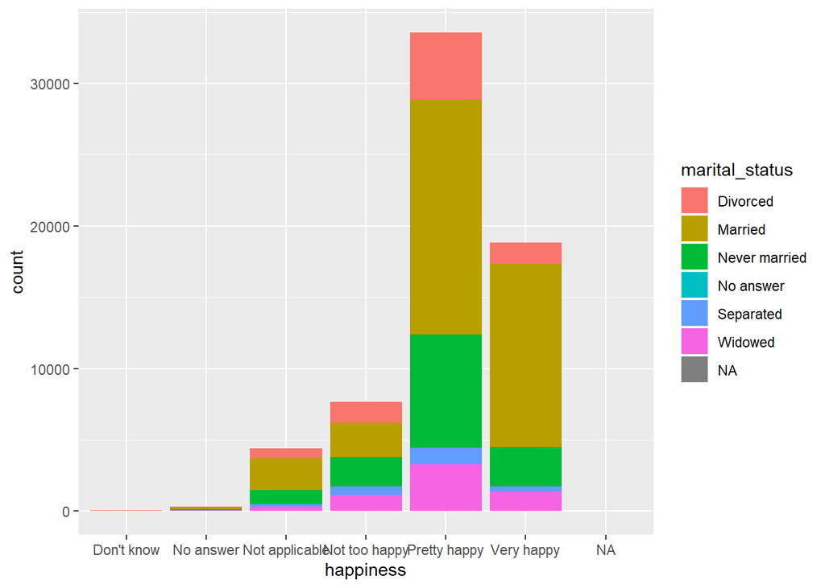

```r
my_plot <- ggplot(data=data,  aes(x=happiness, fill=marital_status))
my_plot + geom_bar()
```

The barchart created here visualizes the relationship between patient individual happiness and marital status. The colors of each bar establish the different statuses of marriage, from divorced, married, never married, separated, and widowed. From the respondents, we see that most respondents are pretty happy, and most that are pretty happy are also married. There are a significant portion of respondents who are pretty and happy, but also divorced or never married. When looking at those who are very happy, the vast majority are married. The majority of those who are not too happy are either married, or never married. Overall, we can conclude that respondents are generally happy, even when they are never married or divorced.

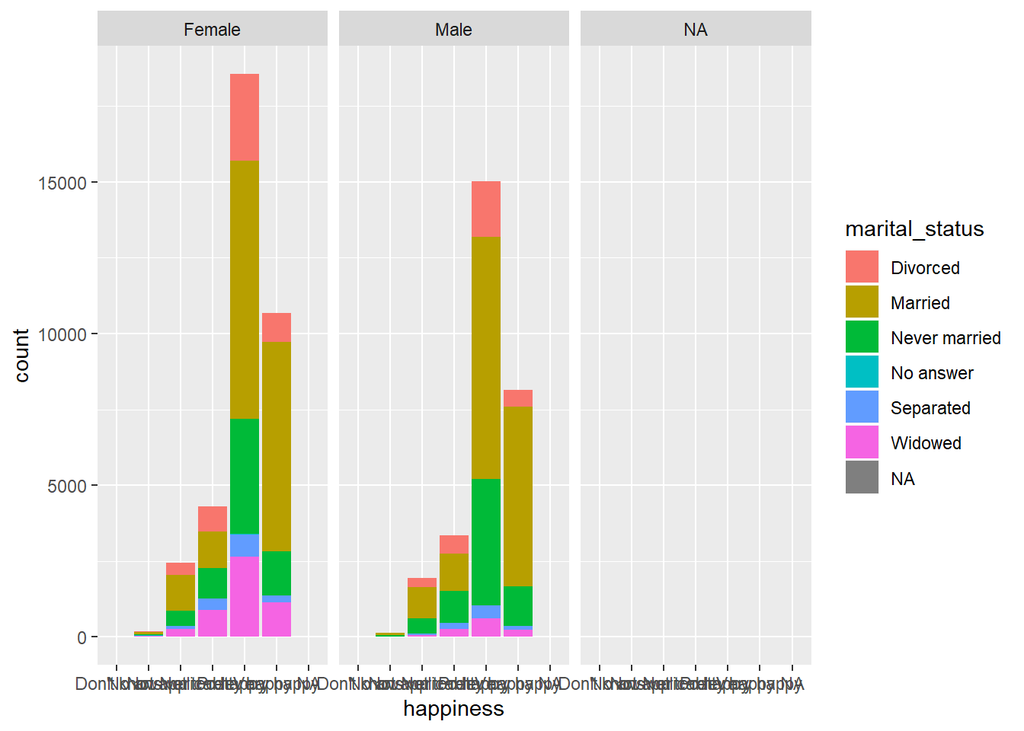

```r
my_plot + geom_bar() + facet_wrap(~sex)
```

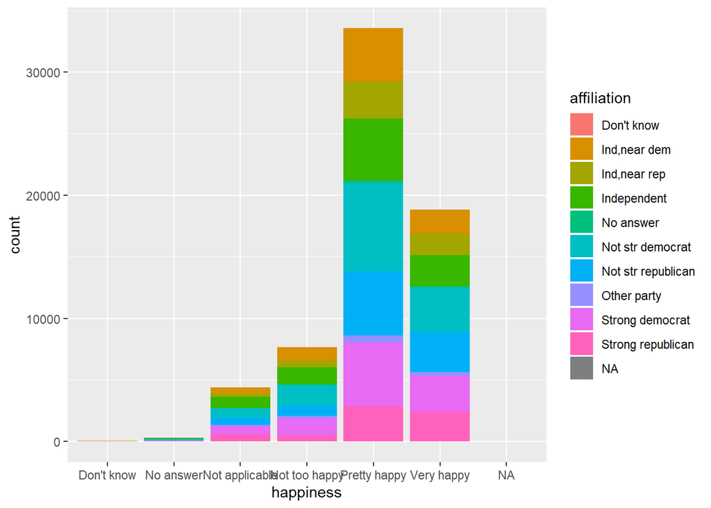

```r
my_plot <- ggplot(data=data,  aes(x=happiness, fill=affiliation))
my_plot + geom_bar()
```

This barchart is visualizing the relationship between respondent happiness and the level of their political party affiliation. We see that again, most respondents are pretty happy or very happy. Much fewer are not too happy. Primarily, those that fall in the pretty happy category are those who are either not strictly democrat/republican, and those who are strong democrats or independent. For very happy, we see an even spread amongst the affiliations. The responses of not strictly democrat/republican, and strong democrat/republican are about equal. For those who are not very happy, we see the again, an even distribution. Those who are not very happy tend to be independent, or not strictly towards either side. Overall, we can conclude that it is difficult to associatite political party affiliation with overall happiness.

How does political party affiliation relate to the sex of the respondent?

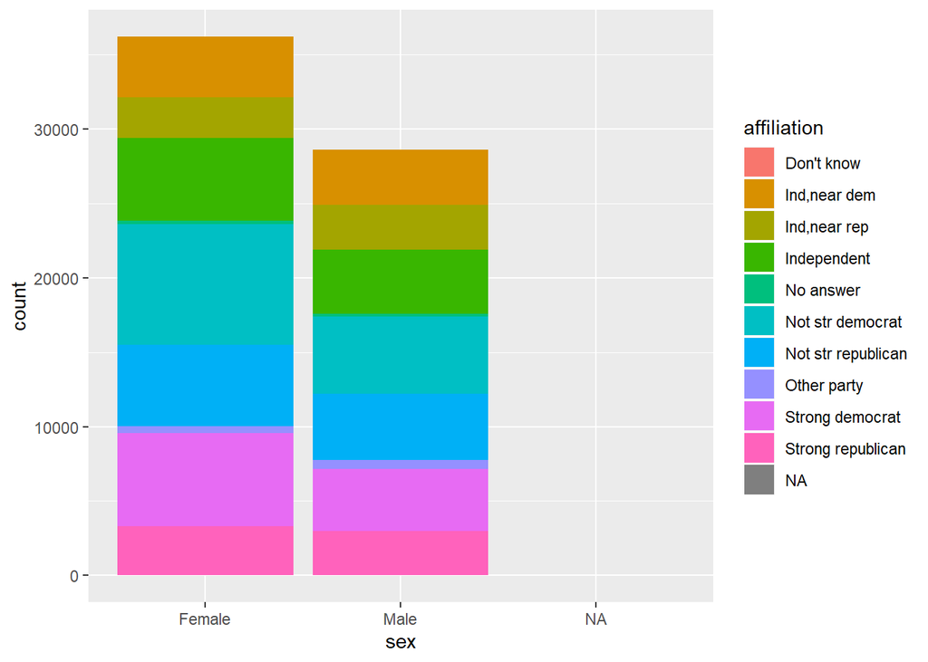

```r
ggplot(data=data,  aes(x=sex, fill=affiliation)) + geom_bar()
```

This barchart visualizes the relationship between levels of political party affiliation based on sex. Starting with the amount of respondents, we see that females responded more frequently than men in this survey. We see many more strong democrats and not strictly democrats in for women than men, whereas men is much closer to 50-50 for democrats and republicans. We also see about equal numbers for independent parties. Overall, we can conclude that women in this survey tend to lean towards the democratic side, whereas the split is more 50-50 for men.

How does marital status relate to the political party affiliation of the respondent?

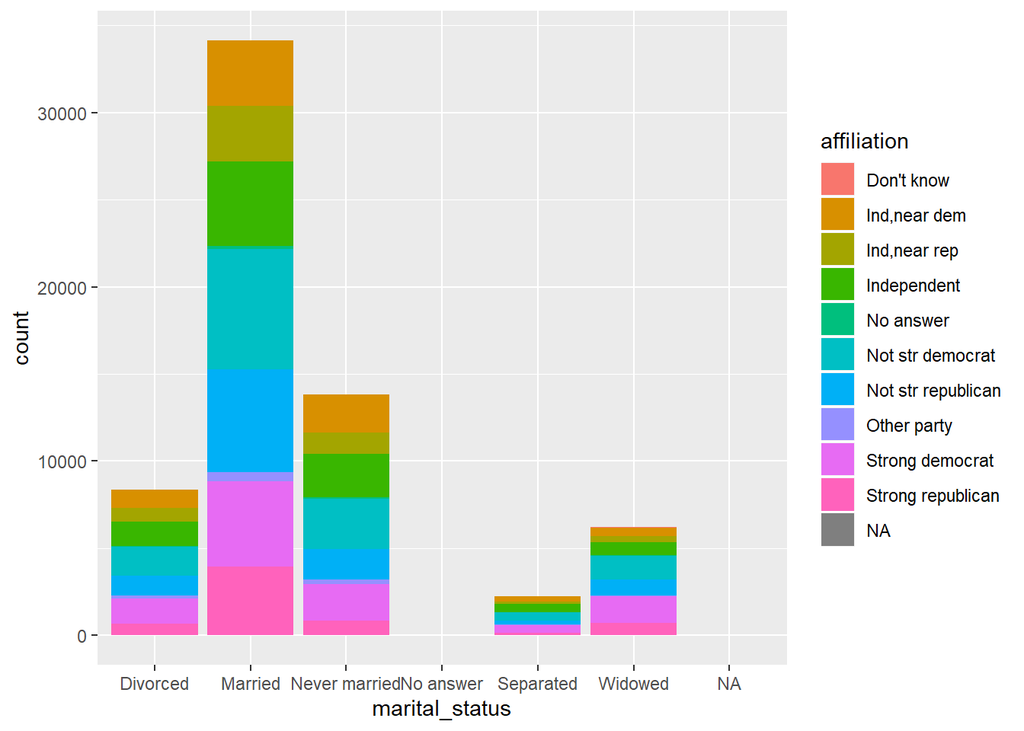

```r
ggplot(data=data,  aes(x=marital_status, fill=affiliation)) + geom_bar()
```

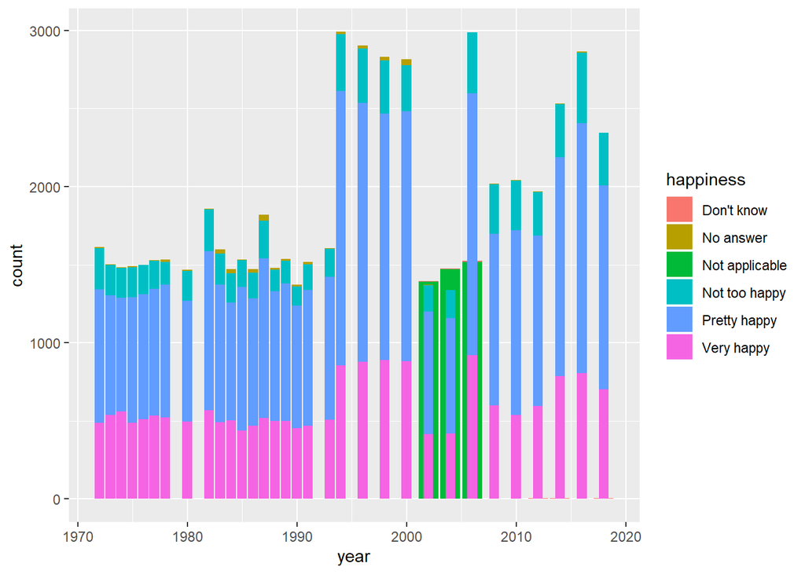

```r
ggplot(data=data,  aes(x=year, fill=happiness)) + geom_bar()
```

This barchart visualizes how respondent happiness has changed over time. While numbers regarding happiness were rather consistent for the first approximately 20 years, around the early 1990s, those who are very happy steadily increased, to a major increase in the mid 1990s. This primarily due to a significant increase in respondents. The distribution of happiness overall, percentage-wise, has remained rather consistent over time.

How does political party affiliation change over time (year)?

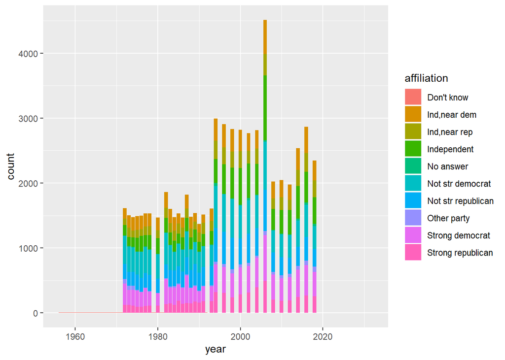

```r
ggplot(data=data,  aes(x=year, fill=affiliation)) + geom_bar()
```